# Analysing survey data with timesaveR

Source: [`vignettes/survey-functions.Rmd`](https://github.com/LukasWallrich/timesaveR/blob/master/vignettes/survey-functions.Rmd)

## Using survey weights

Large-scale social surveys often do not aim to recruit random samples, but rather oversample small groups that are of interest for sub-group analyses (e.g., ethnic minorities). In addition, they never quite succeed in recruiting representative samples. To ensure that the results of statistical models approximate population parameters, survey weights need to be used to give each participant a specific weight in analyses. You can find out more in this [brief YouTube video](https://youtu.be/brxx81U6N1o) or explore the more [extensive guide to weights in the European Social Survey](https://www.europeansocialsurvey.org/methodology/ess_methodology/data_processing_archiving/weighting.html) as an example.

## Survey weights in timesaveR

Many functions in the `timesaveR` package have alternatives that accept survey objects instead of dataframes. These functions are designated by the `svy_` prefix. The `svy_` functions ensure that all calculations (means, correlations, tests) account for survey weights, providing accurate population estimates rather than sample statistics. To use them, you will first need to use the `srvyr` package to create a survey object based on the dataframe.

Below, I show some analyses of the European Social Survey 2014 data using the correct survey weights.

```r
library(timesaveR)
library(srvyr)

#Create weights (consists of two variables in ESS)
ess_health$svy_weight <- ess_health$pspwght * ess_health$pweight

ess_survey <- as_survey(ess_health,
                        weights = svy_weight)
```

## Create scales

Let’s create scales for health behaviours and depressive symptoms, each including some reverse coding. For that, we need to pass the survey items (as well as any to be reversed) to the `svy_make_scale()` function

```r
  depression_items = c("fltdpr", "flteeff", "slprl", "wrhpp", "fltlnl",
                 "enjlf", "fltsd", "cldgng")

  healthy_eating_items = c("etfruit", "eatveg")

  depression_reversed = c("wrhpp", "enjlf")
```

Then, the `svy_make_scale()` command can be used to **calculate scale scores and display descriptives**. It returns the survey object with the new variable added, so that you can use a pipeline to create multiple scales.

```r
ess_survey <- svy_make_scale(ess_survey, depression_items,
                             "depression", reversed = depression_reversed) %>%
  svy_make_scale(healthy_eating_items, "healthy_eating",
                 r_key = -1)  # r_key = -1 reverses the entire scale after creation
```

[figure not shown]

```
#> Descriptives for healthy_eating scale:
#> Mean: 4.931  SD: 1.131
#> Cronbach's alpha: .66
```

[figure not shown]

## Report correlations

You can use `svy_cor_matrix()` to calculate weighted correlations, and then use `report_cor_table()` to present them nicely.

```r
ess_survey %>%
  select(agea, health, depression, healthy_eating) %>%
  svy_cor_matrix() %>%
  report_cor_table()
```

Variable

*M (SD)*

1

2

3

1. agea

47.87 (18.98)

2. health

2.23 (0.91)

.30 ***  
[0.28, 0.32]

3. depression

1.66 (0.48)

.05 ***  
[0.02, 0.07]

.41 ***  
[0.39, 0.44]

4. healthy_eating

4.93 (1.13)

.17 ***  
[0.15, 0.19]

-.09 ***  
[-0.11, -0.07]

-.11 ***  
[-0.13, -0.08]

*M* and *SD* are used to represent mean and standard deviation, respectively.

Values in square brackets indicate the confidence interval for each correlation.

† *p* < .1, * *p* < .05, ** *p* < .01, *** *p* < .001

It is often helpful to use different variable names for display. For this, functions in the package typically accept rename tibbles that contain an `old` and a `new` column. By using the `tibble::tribble` notation, they can be entered more cleanly than named character vectors, and the `get_rename_tribble()` helper function creates most of the code.

```r
# Call
# get_rename_tribbles(ess_health, agea, health, depression, healthy_eating, which = "vars")
# to get most of this code

var_renames <- tibble::tribble(
  ~old,             ~new,
   "agea",           "Age",
   "health",         "Poor health",
   "depression",     "Depression",
   "healthy_eating",  "Healthy eating"
)

# If var_names are provided, only variables included in that argument
# are included in the correlation table
ess_survey %>% svy_cor_matrix(var_names = var_renames) %>%
  report_cor_table()
```

Variable

*M (SD)*

1

2

3

1. Age

47.87 (18.98)

2. Poor health

2.23 (0.91)

.30 ***  
[0.28, 0.32]

3. Depression

1.66 (0.48)

.41 ***  
[0.39, 0.44]

4. Healthy eating

4.93 (1.13)

.17 ***  
[0.15, 0.19]

-.09 ***  
[-0.11, -0.07]

-.11 ***  
[-0.13, -0.08]

*M* and *SD* are used to represent mean and standard deviation, respectively.

Values in square brackets indicate the confidence interval for each correlation.

† *p* < .1, * *p* < .05, ** *p* < .01, *** *p* < .001

### Adding distribution plots

You can add distribution plots to correlation tables for survey data. These distributions are properly weighted using `svyhist()` for discrete variables and `svysmooth()` for continuous variables, ensuring they reflect the population rather than just the sample composition.

```r
ess_survey %>% svy_cor_matrix(var_names = var_renames) %>%
  report_cor_table(add_distributions = TRUE, data = ess_survey)
```

Variable

*M (SD)*

Distributions

1

2

3

1. Age

47.87 (18.98)

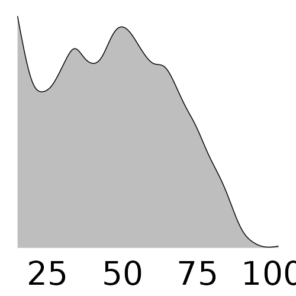

2. Poor health

2.23 (0.91)

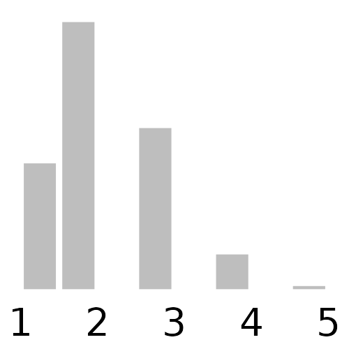

.30 ***  
[0.28, 0.32]

3. Depression

1.66 (0.48)

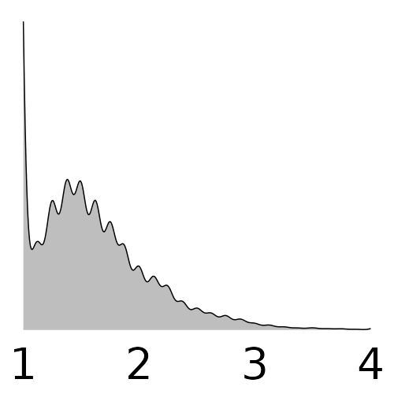

.05 ***  
[0.02, 0.07]

.41 ***  
[0.39, 0.44]

4. Healthy eating

4.93 (1.13)

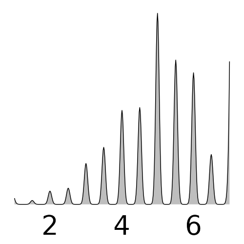

.17 ***  
[0.15, 0.19]

-.11 ***  
[-0.13, -0.08]

*M* and *SD* are used to represent mean and standard deviation, respectively.

Values in square brackets indicate the confidence interval for each correlation.

† *p* < .1, * *p* < .05, ** *p* < .01, *** *p* < .001

The `plot_distributions()` function can also be used directly with survey data:

```r
plot_distributions(ess_survey, var_names = var_renames)
```

[figure not shown]

```
#>
#> $`Poor health`
```

[figure not shown]

[figure not shown]

```
#>
#> $`Healthy eating`
```

[figure not shown]

These plots properly account for survey weights, so the distributions shown represent population estimates rather than raw sample frequencies.

## Testing significance of difference between two groups

Running a t-test on survey data is easy with `survey::svyttest()`. However, getting Cohen’s *d* as a measure of effect size, or subsetting to compare just two levels if there are more in the data is less trivial, and is where `svy_cohen_d_pair()` comes in.

```r
# Returns Cohen's d in the 'd' column
svy_cohen_d_pair(ess_survey, "health", "gndr")
```

```
#> # A tibble: 1 × 8
#>   pair       d      t    df p.value mean_diff mean_diff_ci.low mean_diff_ci.high
#>   <chr>  <dbl>  <dbl> <dbl>   <dbl>     <dbl>            <dbl>             <dbl>
#> 1 1 & 2 -0.133 -0.120  7217 1.40e-6    -0.120          -0.0714            -0.169
```

```r
svy_cohen_d_pair(ess_survey, "health", "cntry", pair = c("DE", "GB"))
```

```
#> # A tibble: 1 × 8
#>   pair       d     t    df  p.value mean_diff mean_diff_ci.low mean_diff_ci.high
#>   <chr>  <dbl> <dbl> <dbl>    <dbl>     <dbl>            <dbl>             <dbl>
#> 1 DE & … 0.324 0.295  5301 7.94e-25     0.295            0.351             0.239
```

## Running pairwise t-tests

`svy_pairwise_t_test()` allows to run pairwise t-tests, e.g., as post-hoc comparisons, between multiple groups in the survey. *p*-values are adjusted for multiple comparisons, by default using the Holm-Bonferroni method.

```r
svy_pairwise_t_test(ess_survey, "health", "cntry", cats = c("DE", "GB", "FR"))
```

```
#> # A tibble: 3 × 8
#>   pair          d       t    df  p.value mean_diff mean_diff_ci.low
#>   <chr>     <dbl>   <dbl> <dbl>    <dbl>     <dbl>            <dbl>
#> 1 DE & GB  0.324   0.295   5301 2.38e-24    0.295             0.351
#> 2 DE & FR  0.0956  0.0849  4954 5.88e- 3    0.0849            0.145
#> 3 GB & FR -0.233  -0.210   4177 3.16e-10   -0.210            -0.146
#> # ℹ 1 more variable: mean_diff_ci.high <dbl>
```